# Hate Crime Trends Over Time (2012–2022)

### Introduction

This analysis explores the distribution of hate crimes reported in California over time, categorized by:

1. Race/Ethnicity/Ancestry
2. LGBTQ Community
3. Religion

The visualizations and statistics aim to identify trends and patterns, offering insights into the dynamics of hate crimes.

```python
import pandas as pd

# Load the datasets
hate_crime_data = pd.read_csv('Hate Crime 2012 - 2022.csv')
ncic_data = pd.read_csv('NCIC Code Jurisdiction List.csv')

# Merge the datasets to associate county names
merged_data = pd.merge(hate_crime_data, ncic_data, left_on='County', right_on='CntyCode', how='left')

# Summary statistics
total_crimes = hate_crime_data.shape[0]
bias_type_counts = hate_crime_data['MostSeriousBiasType'].value_counts().reset_index()
bias_type_counts.columns = ['BiasType', 'Count']  # Rename columns for clarity
top_counties = merged_data.groupby('County_y').size().sort_values(ascending=False).head(5)
top_counties_df = top_counties.reset_index(name='HateCrimeCount')  # Convert to DataFrame

# Minority statistics
minority_biases = [
    "Anti-Black or African American",
    "Anti-White",
    "Anti-Hispanic or Latino",
    "Anti-Multiple Races (Group)",
    "Anti-Asian",
    "Anti-Other Race/Ethnicity/Ancestry",
    "Anti-Gay (Male)",
    "Anti-Transgender",
    "Anti-Lesbian/Gay/Bisexual or Transgender (Mixed Group)",
    "Anti-Citizenship Status",
    "Anti-Bisexual",
    "Anti-Jewish",
    "Anti-Arab",
    "Anti-Catholic"
]
minority_data = hate_crime_data[hate_crime_data['MostSeriousBias'].isin(minority_biases)]
minority_counts = minority_data['MostSeriousBias'].value_counts().reset_index()
minority_counts.columns = ['Bias', 'Count']  # Rename columns for clarity
```

### Displaying Results

This section prints the processed summary statistics for easy viewing:

1. **Total Hate Crimes**:
   - Displays the total number of hate crimes in the dataset using `total_crimes`.
2. **Hate Crimes by Bias Type**:
   - Prints the number of hate crimes for each bias type (e.g., Race/Ethnicity, Religion).

```python
print(f"Total Hate Crimes: {total_crimes}")
print("\nHate Crimes by Bias Type:\n")
print(bias_type_counts.to_string(index=False))  # Print without index
```

```
Total Hate Crimes: 12706

Hate Crimes by Bias Type:

               BiasType  Count
Race/Ethnicity/Ancestry   7466
     Sexual Orientation   2662
               Religion   2088
   Gender Nonconforming    375
             Disability     63
                 Gender     52
```

### Displaying Top 5 Counties with Most Hate Crimes

This section prints the top 5 counties with the highest number of hate crimes:

1. **Top 5 Counties**:
   - `top_counties_df` contains the county names and their respective hate crime counts.

The output highlights which regions in California report the most hate crimes.

```python
print("\nTop 5 Counties with Most Hate Crimes:\n")
print(top_counties_df.to_string(index=False))  # Print without index
```

```
Top 5 Counties with Most Hate Crimes:

          County_y  HateCrimeCount
Los Angeles County            4918
  San Diego County            1000
Santa Clara County             835
    Alameda County             707
     Orange County             646
```

### Displaying Hate Crimes Against Minorities

This section prints a summary of hate crimes targeting specific minority groups:

1. **Minority Bias Data**:
   - `minority_counts` contains the bias types and their respective hate crime counts.

The output provides insights into the groups most affected by hate crimes, such as Anti-Black, Anti-Asian, and Anti-LGBTQ biases.

```python
print("\nHate Crimes Against Minorities:\n")
print(minority_counts.to_string(index=False))  # Print minority data without index
```

```
Hate Crimes Against Minorities:

                                                  Bias  Count
                        Anti-Black or African American   3753
                                       Anti-Gay (Male)   1725
                               Anti-Hispanic or Latino   1324
                                           Anti-Jewish   1249
                                            Anti-Asian    707
Anti-Lesbian/Gay/Bisexual or Transgender (Mixed Group)    611
                                            Anti-White    602
                    Anti-Other Race/Ethnicity/Ancestry    478
                                      Anti-Transgender    339
                           Anti-Multiple Races (Group)    293
                                             Anti-Arab    184
                                         Anti-Catholic    121
                               Anti-Citizenship Status     75
                                         Anti-Bisexual     34
```

### Visualizing Hate Crimes Against Minorities

This section creates a horizontal bar chart to display the number of hate crimes targeting specific minority groups: This visualization highlights disparities in hate crimes against different minority groups.

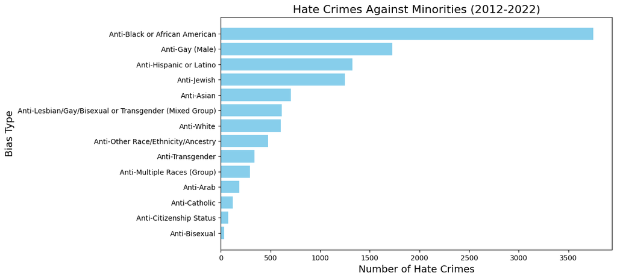

```python
import matplotlib.pyplot as plt

# Plot the data
plt.figure(figsize=(10, 6))
plt.barh(minority_counts['Bias'], minority_counts['Count'], color='skyblue')
plt.title('Hate Crimes Against Minorities (2012-2022)', fontsize=16)
plt.xlabel('Number of Hate Crimes', fontsize=14)
plt.ylabel('Bias Type', fontsize=14)
plt.gca().invert_yaxis()  # Flip y-axis for better readability
plt.show()
```

### Visualizing Trends in Hate Crimes Against Minorities Over Time

This section uses a line chart to show the trends in hate crimes targeting different minority groups from 2012 to 2022.

1. **Data Preparation**:
   - `trend_data`: Groups the dataset by bias type (`MostSeriousBias`) and year (`ClosedYear`), and counts the number of hate crimes.

This visualization highlights how hate crimes against minorities have evolved over time and identifies trends for specific bias types.

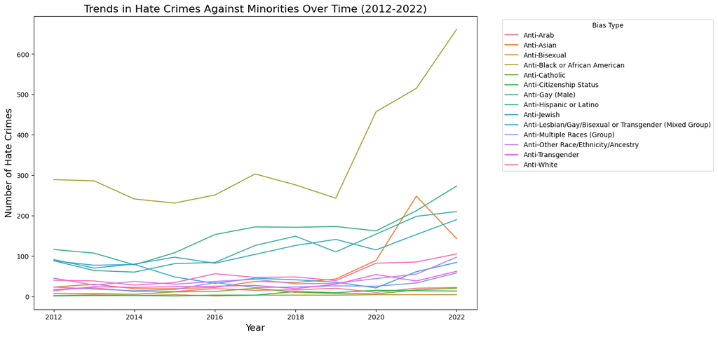

```python
import seaborn as sns

trend_data = minority_data.groupby(['MostSeriousBias', 'ClosedYear']).size().reset_index(name='Count')


plt.figure(figsize=(12, 8))
sns.lineplot(data=trend_data, x='ClosedYear', y='Count', hue='MostSeriousBias')
plt.title('Trends in Hate Crimes Against Minorities Over Time (2012-2022)', fontsize=16)
plt.xlabel('Year', fontsize=14)
plt.ylabel('Number of Hate Crimes', fontsize=14)
plt.legend(title='Bias Type', bbox_to_anchor=(1.05, 1), loc='upper left')
plt.show()
```